```python
# Import Packages
import pandas as pd, numpy as np, matplotlib.pyplot as plt, seaborn as sns, gc
from scipy import stats; from scipy.stats import zscore, norm, randint
import matplotlib.style as style; style.use('fivethirtyeight')
from sklearn.impute import SimpleImputer
from sklearn.decomposition import PCA
%matplotlib inline

# Models
from sklearn.model_selection import train_test_split, GridSearchCV, StratifiedKFold, cross_val_score, learning_curve
from sklearn.metrics import classification_report, confusion_matrix, roc_auc_score, roc_curve, accuracy_score
from sklearn.ensemble import RandomForestClassifier
from sklearn.linear_model import LogisticRegression
from sklearn.neighbors import KNeighborsClassifier
from sklearn.preprocessing import StandardScaler
from sklearn.tree import DecisionTreeClassifier
from sklearn.naive_bayes import GaussianNB
from sklearn.svm import SVC

# Display settings
pd.options.display.max_rows = 500
pd.options.display.max_columns = 200
pd.options.display.float_format = "{:.2f}".format

random_state = 42
np.random.seed(random_state)

# Suppress warnings
import warnings; warnings.filterwarnings('ignore')
```

# 1. Data pre-processing – Perform all the necessary preprocessing on the data ready to be fed to an Unsupervised algorithm

```python
#Reading the data  and display the first five rows
vehicle = pd.read_csv('vehicle.csv')
vehicle.head()
```

|  | compactness | circularity | distance_circularity | radius_ratio | pr.axis_aspect_ratio | max.length_aspect_ratio | scatter_ratio | elongatedness | pr.axis_rectangularity | max.length_rectangularity | scaled_variance | scaled_variance.1 | scaled_radius_of_gyration | scaled_radius_of_gyration.1 | skewness_about | skewness_about.1 | skewness_about.2 | hollows_ratio | class |
| --- | --- | --- | --- | --- | --- | --- | --- | --- | --- | --- | --- | --- | --- | --- | --- | --- | --- | --- | --- |
| 0 | 95 | 48.00 | 83.00 | 178.00 | 72.00 | 10 | 162.00 | 42.00 | 20.00 | 159 | 176.00 | 379.00 | 184.00 | 70.00 | 6.00 | 16.00 | 187.00 | 197 | van |
| 1 | 91 | 41.00 | 84.00 | 141.00 | 57.00 | 9 | 149.00 | 45.00 | 19.00 | 143 | 170.00 | 330.00 | 158.00 | 72.00 | 9.00 | 14.00 | 189.00 | 199 | van |
| 2 | 104 | 50.00 | 106.00 | 209.00 | 66.00 | 10 | 207.00 | 32.00 | 23.00 | 158 | 223.00 | 635.00 | 220.00 | 73.00 | 14.00 | 9.00 | 188.00 | 196 | car |
| 3 | 93 | 41.00 | 82.00 | 159.00 | 63.00 | 9 | 144.00 | 46.00 | 19.00 | 143 | 160.00 | 309.00 | 127.00 | 63.00 | 6.00 | 10.00 | 199.00 | 207 | van |
| 4 | 85 | 44.00 | 70.00 | 205.00 | 103.00 | 52 | 149.00 | 45.00 | 19.00 | 144 | 241.00 | 325.00 | 188.00 | 127.00 | 9.00 | 11.00 | 180.00 | 183 | bus |

```python
vehicle.columns
```

```
Index(['compactness', 'circularity', 'distance_circularity', 'radius_ratio',
       'pr.axis_aspect_ratio', 'max.length_aspect_ratio', 'scatter_ratio',
       'elongatedness', 'pr.axis_rectangularity', 'max.length_rectangularity',
       'scaled_variance', 'scaled_variance.1', 'scaled_radius_of_gyration',
       'scaled_radius_of_gyration.1', 'skewness_about', 'skewness_about.1',
       'skewness_about.2', 'hollows_ratio', 'class'],
      dtype='object')
```

```python
#Get info of the dataframe columns and check missing values
vehicle.info()
```

```
<class 'pandas.core.frame.DataFrame'>
RangeIndex: 846 entries, 0 to 845
Data columns (total 19 columns):
 #   Column                       Non-Null Count  Dtype
---  ------                       --------------  -----
 0   compactness                  846 non-null    int64
 1   circularity                  841 non-null    float64
 2   distance_circularity         842 non-null    float64
 3   radius_ratio                 840 non-null    float64
 4   pr.axis_aspect_ratio         844 non-null    float64
 5   max.length_aspect_ratio      846 non-null    int64
 6   scatter_ratio                845 non-null    float64
 7   elongatedness                845 non-null    float64
 8   pr.axis_rectangularity       843 non-null    float64
 9   max.length_rectangularity    846 non-null    int64
 10  scaled_variance              843 non-null    float64
 11  scaled_variance.1            844 non-null    float64
 12  scaled_radius_of_gyration    844 non-null    float64
 13  scaled_radius_of_gyration.1  842 non-null    float64
 14  skewness_about               840 non-null    float64
 15  skewness_about.1             845 non-null    float64
 16  skewness_about.2             845 non-null    float64
 17  hollows_ratio                846 non-null    int64
 18  class                        846 non-null    object
dtypes: float64(14), int64(4), object(1)
memory usage: 125.7+ KB
```

```python
#Dataset shape
vehicle.shape
```

```
(846, 19)
```

Vehicle Dataset has 846 rows and 19 columns with missing values in several columns.

```python
# Checking missing values in dataframe
vehicle.isnull().sum()
```

```
compactness                    0
circularity                    5
distance_circularity           4
radius_ratio                   6
pr.axis_aspect_ratio           2
max.length_aspect_ratio        0
scatter_ratio                  1
elongatedness                  1
pr.axis_rectangularity         3
max.length_rectangularity      0
scaled_variance                3
scaled_variance.1              2
scaled_radius_of_gyration      2
scaled_radius_of_gyration.1    4
skewness_about                 6
skewness_about.1               1
skewness_about.2               1
hollows_ratio                  0
class                          0
dtype: int64
```

compactness, max.length_aspect_ratio, max.length_rectangularity, hollows_ratio, class has no missing values, rest all features have any missing values. All features are of numerical types.

```python
#Five point summary of numerical attributes
vehicle.describe(include = 'all').T
```

|  | count | unique | top | freq | mean | std | min | 25% | 50% | 75% | max |
| --- | --- | --- | --- | --- | --- | --- | --- | --- | --- | --- | --- |
| compactness | 846.00 | NaN | NaN | NaN | 93.68 | 8.23 | 73.00 | 87.00 | 93.00 | 100.00 | 119.00 |
| circularity | 841.00 | NaN | NaN | NaN | 44.83 | 6.15 | 33.00 | 40.00 | 44.00 | 49.00 | 59.00 |
| distance_circularity | 842.00 | NaN | NaN | NaN | 82.11 | 15.78 | 40.00 | 70.00 | 80.00 | 98.00 | 112.00 |
| radius_ratio | 840.00 | NaN | NaN | NaN | 168.89 | 33.52 | 104.00 | 141.00 | 167.00 | 195.00 | 333.00 |
| pr.axis_aspect_ratio | 844.00 | NaN | NaN | NaN | 61.68 | 7.89 | 47.00 | 57.00 | 61.00 | 65.00 | 138.00 |
| max.length_aspect_ratio | 846.00 | NaN | NaN | NaN | 8.57 | 4.60 | 2.00 | 7.00 | 8.00 | 10.00 | 55.00 |
| scatter_ratio | 845.00 | NaN | NaN | NaN | 168.90 | 33.21 | 112.00 | 147.00 | 157.00 | 198.00 | 265.00 |
| elongatedness | 845.00 | NaN | NaN | NaN | 40.93 | 7.82 | 26.00 | 33.00 | 43.00 | 46.00 | 61.00 |
| pr.axis_rectangularity | 843.00 | NaN | NaN | NaN | 20.58 | 2.59 | 17.00 | 19.00 | 20.00 | 23.00 | 29.00 |
| max.length_rectangularity | 846.00 | NaN | NaN | NaN | 148.00 | 14.52 | 118.00 | 137.00 | 146.00 | 159.00 | 188.00 |
| scaled_variance | 843.00 | NaN | NaN | NaN | 188.63 | 31.41 | 130.00 | 167.00 | 179.00 | 217.00 | 320.00 |
| scaled_variance.1 | 844.00 | NaN | NaN | NaN | 439.49 | 176.67 | 184.00 | 318.00 | 363.50 | 587.00 | 1018.00 |
| scaled_radius_of_gyration | 844.00 | NaN | NaN | NaN | 174.71 | 32.58 | 109.00 | 149.00 | 173.50 | 198.00 | 268.00 |
| scaled_radius_of_gyration.1 | 842.00 | NaN | NaN | NaN | 72.45 | 7.49 | 59.00 | 67.00 | 71.50 | 75.00 | 135.00 |
| skewness_about | 840.00 | NaN | NaN | NaN | 6.36 | 4.92 | 0.00 | 2.00 | 6.00 | 9.00 | 22.00 |
| skewness_about.1 | 845.00 | NaN | NaN | NaN | 12.60 | 8.94 | 0.00 | 5.00 | 11.00 | 19.00 | 41.00 |
| skewness_about.2 | 845.00 | NaN | NaN | NaN | 188.92 | 6.16 | 176.00 | 184.00 | 188.00 | 193.00 | 206.00 |
| hollows_ratio | 846.00 | NaN | NaN | NaN | 195.63 | 7.44 | 181.00 | 190.25 | 197.00 | 201.00 | 211.00 |
| class | 846 | 3 | car | 429 | NaN | NaN | NaN | NaN | NaN | NaN | NaN |

Descriptive statistics for the numerical variables

compactness: Range of Q1 to Q3 is between 87 to 100. It appears that the column is almost normally distributed.

circularity: Range of Q1 to Q3 is 40 to 49. This column too appears to be almost normally distributed.

distance_circularity: Range of Q1 to Q3 is 70 to 98. Mean is slightly greater than median, we can say that the column is slightly skewed towards right.

radius_ratio: Range of Q1 to Q3 is 141 to 195. Mean is slightly greater than median, we can say that the column is slightly skewed towards right.

pr.axis_aspect_ratio: Range of Q1 to Q3 is 57 to 65. Mean is slightly greater than median, we can say that the column is slightly skewed towards right.

max.length_aspect_ratio: Range of Q1 to Q3 is 7 to 10. Mean is slightly greater than median, we can say that the column is slightly skewed towards right.

scatter_ratio: Range of Q1 to Q3 is 147 to 198. Mean is greater than median, we can say that the column is skewed towards right.

elongatedness: Range of Q1 to Q3 is 33 to 46. Mean is less than median, we can say that the column is skewed towards left.

pr.axis_rectangularity: Range of Q1 to Q3 is 19 to 23. Mean is greater than median, we can say that the column is skewed towards right.

max.length_rectangularity: Range of Q1 to Q3 is 137 to 159. Mean is greater than median, we can say that the column is skewed towards right.

scaled_variance: Range of Q1 to Q3 is 167 to 217. Mean is grater than median, we can say that the column is skewed towards right.

scaled_variance.1: Range of Q1 to Q3 is 318 to 587. Mean is greater than median, we can say that the column is skewed towards right.

scaled_radius_of_gyration: Range of Q1 to Q3 is 149 to 198. Mean is greater than median, we can say that the column is skewed towards right.

scaled_radius_of_gyration.1: Range of Q1 to Q3 is 67 to 75. Mean is greater than median, we can say that the column is skewed towards right.

skewness_about.1: Range of Q1 to Q3 is 5 to 19. Mean is greater than median, skewed towards right.

skewness_about.2: Range of Q1 to Q3 is 184 to 193. Mean is slightly greater than median, almost normally distributed.

```python
#Analyzing the Target Column = 'Class 'unique (categorical) values
columns = vehicle.loc[:, vehicle.dtypes == 'object'].columns.tolist()
for cols in columns:
    print(f'Unique values for {cols} is \n{vehicle[cols].unique()}\n')
del cols, columns
```

```
Unique values for class is
['van' 'car' 'bus']
```

class is a target variable and has three unique values.

```python
#checking the distribution of class variable
display(vehicle['class'].value_counts(), vehicle['class'].value_counts(normalize = True)*100)
```

```
car    429
bus    218
van    199
Name: class, dtype: int64
```

```
car   50.71
bus   25.77
van   23.52
Name: class, dtype: float64
```

car represents about 50.7% of the total values in class variable, bus about 25.8% and van about 23.5%.

```python
#Re-assigning Target attribute(class) from categorical to numerical value
replace_structure = {'car': 3, 'bus': 2, 'van': 1}
vehicle['class'] = vehicle['class'].map(replace_structure)
del replace_structure
```

```python
null_col = vehicle.columns[vehicle.isnull().any()]; columns = list(vehicle.columns)

print('Descriptive Statistics before imputation for attributes with missing values: \n', '--'*30)
display(vehicle[null_col].describe().T)

# Using SimpleImputer to fill missing values by median
impute = SimpleImputer(missing_values = np.nan, strategy = 'median', verbose = 1)
vehicle = pd.DataFrame(impute.fit_transform(vehicle), columns = columns)

print('Descriptive Statistics after imputation: \n', '--'*30)
display(vehicle[null_col].describe().T)
```

```
Descriptive Statistics before imputation for attributes with missing values:
 ------------------------------------------------------------
```

|  | count | mean | std | min | 25% | 50% | 75% | max |
| --- | --- | --- | --- | --- | --- | --- | --- | --- |
| circularity | 841.00 | 44.83 | 6.15 | 33.00 | 40.00 | 44.00 | 49.00 | 59.00 |
| distance_circularity | 842.00 | 82.11 | 15.78 | 40.00 | 70.00 | 80.00 | 98.00 | 112.00 |
| radius_ratio | 840.00 | 168.89 | 33.52 | 104.00 | 141.00 | 167.00 | 195.00 | 333.00 |
| pr.axis_aspect_ratio | 844.00 | 61.68 | 7.89 | 47.00 | 57.00 | 61.00 | 65.00 | 138.00 |
| scatter_ratio | 845.00 | 168.90 | 33.21 | 112.00 | 147.00 | 157.00 | 198.00 | 265.00 |
| elongatedness | 845.00 | 40.93 | 7.82 | 26.00 | 33.00 | 43.00 | 46.00 | 61.00 |
| pr.axis_rectangularity | 843.00 | 20.58 | 2.59 | 17.00 | 19.00 | 20.00 | 23.00 | 29.00 |
| scaled_variance | 843.00 | 188.63 | 31.41 | 130.00 | 167.00 | 179.00 | 217.00 | 320.00 |
| scaled_variance.1 | 844.00 | 439.49 | 176.67 | 184.00 | 318.00 | 363.50 | 587.00 | 1018.00 |
| scaled_radius_of_gyration | 844.00 | 174.71 | 32.58 | 109.00 | 149.00 | 173.50 | 198.00 | 268.00 |
| scaled_radius_of_gyration.1 | 842.00 | 72.45 | 7.49 | 59.00 | 67.00 | 71.50 | 75.00 | 135.00 |
| skewness_about | 840.00 | 6.36 | 4.92 | 0.00 | 2.00 | 6.00 | 9.00 | 22.00 |
| skewness_about.1 | 845.00 | 12.60 | 8.94 | 0.00 | 5.00 | 11.00 | 19.00 | 41.00 |
| skewness_about.2 | 845.00 | 188.92 | 6.16 | 176.00 | 184.00 | 188.00 | 193.00 | 206.00 |

```
Descriptive Statistics after imputation:
 ------------------------------------------------------------
```

|  | count | mean | std | min | 25% | 50% | 75% | max |
| --- | --- | --- | --- | --- | --- | --- | --- | --- |
| circularity | 846.00 | 44.82 | 6.13 | 33.00 | 40.00 | 44.00 | 49.00 | 59.00 |
| distance_circularity | 846.00 | 82.10 | 15.74 | 40.00 | 70.00 | 80.00 | 98.00 | 112.00 |
| radius_ratio | 846.00 | 168.87 | 33.40 | 104.00 | 141.00 | 167.00 | 195.00 | 333.00 |
| pr.axis_aspect_ratio | 846.00 | 61.68 | 7.88 | 47.00 | 57.00 | 61.00 | 65.00 | 138.00 |
| scatter_ratio | 846.00 | 168.89 | 33.20 | 112.00 | 147.00 | 157.00 | 198.00 | 265.00 |
| elongatedness | 846.00 | 40.94 | 7.81 | 26.00 | 33.00 | 43.00 | 46.00 | 61.00 |
| pr.axis_rectangularity | 846.00 | 20.58 | 2.59 | 17.00 | 19.00 | 20.00 | 23.00 | 29.00 |
| scaled_variance | 846.00 | 188.60 | 31.36 | 130.00 | 167.00 | 179.00 | 217.00 | 320.00 |
| scaled_variance.1 | 846.00 | 439.31 | 176.50 | 184.00 | 318.25 | 363.50 | 586.75 | 1018.00 |
| scaled_radius_of_gyration | 846.00 | 174.71 | 32.55 | 109.00 | 149.00 | 173.50 | 198.00 | 268.00 |
| scaled_radius_of_gyration.1 | 846.00 | 72.44 | 7.47 | 59.00 | 67.00 | 71.50 | 75.00 | 135.00 |
| skewness_about | 846.00 | 6.36 | 4.90 | 0.00 | 2.00 | 6.00 | 9.00 | 22.00 |
| skewness_about.1 | 846.00 | 12.60 | 8.93 | 0.00 | 5.00 | 11.00 | 19.00 | 41.00 |
| skewness_about.2 | 846.00 | 188.92 | 6.15 | 176.00 | 184.00 | 188.00 | 193.00 | 206.00 |

After Imputation,medians remain unchanged while mean changes slightly not significantly. Type of skewness remain unchanged.

# 2. Understanding the attributes - Find relationship between different attributes (Independent variables) and choose carefully which all attributes have to be a part of the analysis and why

```python
#  Function for Exploratory Data Analysis to understand the relationship between different Independent variables
def odp_plots(df, col):
    f,(ax1, ax2, ax3) = plt.subplots(1, 3, figsize = (15, 7.2))

    # Boxplot to check outliers
    sns.boxplot(x = col, data = df, ax = ax1, orient = 'v', color = 'darkslategrey')

    # Distribution plot with outliers
    sns.distplot(df[col], ax = ax2, color = 'teal', fit = norm).set_title(f'{col} with outliers')

    # Removing outliers, but in a new dataframe
    upperbound, lowerbound = np.percentile(df[col], [1, 99])
    y = pd.DataFrame(np.clip(df[col], upperbound, lowerbound))

    # Distribution plot without outliers
    sns.distplot(y[col], ax = ax3, color = 'tab:orange', fit = norm).set_title(f'{col} without outliers')

    kwargs = {'fontsize':14, 'color':'black'}
    ax1.set_title(col + ' Boxplot Analysis', **kwargs)
    ax1.set_xlabel('Box', **kwargs)
    ax1.set_ylabel(col + ' Values', **kwargs)

    return plt.show()

# Function for  Independent variables distribution with target column
def target_plot(df, col1, col2, col3, target = 'class'):
    f,(ax1, ax2, ax3) = plt.subplots(1, 3, figsize = (15, 7.2))
    f.suptitle(f'Distribution for Car, Bus, Van for {col1.capitalize()}, {col2.capitalize()}, {col3.capitalize()}',
               fontsize = 14)
    # Distribution for col1 considering outliers
    sns.distplot(df[(df[target] == 3)][col1], color = 'c', ax = ax1, hist = False,
                 label = 'Car').set_title(f'{col1.capitalize()}')
    sns.distplot(df[(df[target] == 2)][col1], color = 'b', ax = ax1, hist = False,
                 label = 'Bus').set_title(f'{col1.capitalize()}')
    sns.distplot(df[(df[target] == 1)][col1], color = 'm', ax = ax1, hist = False,
                 label = 'Van').set_title(f'{col1.capitalize()}')

    # Distribution for col2 considering outliers
    sns.distplot(df[(df[target] == 3)][col2], color = 'c', ax = ax2, hist = False,
                 label = 'Car').set_title(f'{col2.capitalize()}')
    sns.distplot(df[(df[target] == 2)][col2], color = 'b', ax = ax2, hist = False,
                 label = 'Bus').set_title(f'{col2.capitalize()}')
    sns.distplot(df[(df[target] == 1)][col2], color = 'm', ax = ax2, hist = False,
                 label = 'Van').set_title(f'{col2.capitalize()}')

    # Distribution for col3 considering outliers
    sns.distplot(df[(df[target] == 3)][col3], color = 'c', ax = ax3, hist = False,
                 label = 'Car').set_title(f'{col3.capitalize()}')
    sns.distplot(df[(df[target] == 2)][col3], color = 'b', ax = ax3, hist = False,
                 label = 'Bus').set_title(f'{col3.capitalize()}')
    sns.distplot(df[(df[target] == 1)][col3], color = 'm', ax = ax3, hist = False,
                 label = 'Van').set_title(f'{col3.capitalize()}')
    return plt.show()

# Correlation matrix for all variables
def correlation_matrix(df, threshold = 0.8):
    corr = df.corr()
    mask = np.zeros_like(corr, dtype = np.bool)
    mask[np.triu_indices_from(mask)] = True
    f, ax = plt.subplots(figsize = (15, 7.2))
    cmap = sns.diverging_palette(220, 10, as_cmap = True)
    sns.heatmap(corr, mask = mask, cmap = cmap, square = True, linewidths = .5, cbar_kws = {"shrink": .5})#, annot = True)
    ax.set_title('Correlation Matrix of Data')

    # Filter for correlation value greater than threshold
    sort = corr.abs().unstack()
    sort = sort.sort_values(kind = "quicksort", ascending = False)
    display(sort[(sort > threshold) & (sort < 1)])

# Helper function for PCA plots
def pca_plots(df, col1, col2, xlabel, ylabel, ax):
    ax.set_xlabel(xlabel); ax.set_ylabel(ylabel)
    ax.set_title(f'{xlabel} vs {ylabel}', fontsize = 14)
    targets = [3, 2, 1]; colors = ['r', 'g', 'b']
    for target, color in zip(targets, colors):
        indicesToKeep = df['class'] == target
        ax.scatter(df.loc[indicesToKeep, col1], df.loc[indicesToKeep, col2], c = color, s = 50)
    ax.legend(targets)

# Helper function to plot learning curve
def plot_learning_curve(estimator, X, y,  ax, ylim = None, cv = None, n_jobs = 1,
                        train_sizes = np.linspace(.1, 1.0, 5), name = 'Naive Bayes \n Principal Compoents Learning Curve'):
    if ylim is not None:
        plt.ylim(*ylim)

    # First Estimator
    train_sizes, train_scores, test_scores = learning_curve(estimator, X, y, cv = cv, n_jobs = n_jobs,
                                                            train_sizes = train_sizes)
    train_scores_mean = np.mean(train_scores, axis = 1)
    train_scores_std = np.std(train_scores, axis = 1)
    test_scores_mean = np.mean(test_scores, axis = 1)
    test_scores_std = np.std(test_scores, axis = 1)

    ax.fill_between(train_sizes, train_scores_mean - train_scores_std, train_scores_mean + train_scores_std,
                     alpha = 0.1, color = '#ff9124')
    ax.fill_between(train_sizes, test_scores_mean - test_scores_std, test_scores_mean + test_scores_std,
                     alpha = 0.1, color = '#2492ff')

    ax.plot(train_sizes, train_scores_mean, 'o-', color = '#ff9124', label = 'Training score')
    ax.plot(train_sizes, test_scores_mean, 'o-', color ='#2492ff', label = 'Cross-validation score')
    ax.set_title(name, fontsize = 14)
    ax.set_xlabel('Training size')
    ax.set_ylabel('Score')
    ax.grid(True)
    ax.legend(loc = 'best')
```

# Univariate and Bivariate Visualization

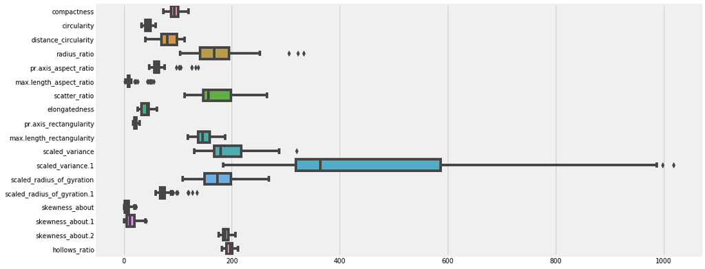

```python
#Checking columns that contain outliers
fig = plt.figure(figsize = (15, 7.2))
ax = sns.boxplot(data = vehicle.iloc[:, 0:18], orient = 'h')
```

```
Radius_ratio column --------------------------------------------------------------------------------
```

```
3
```

|  | compactness | circularity | distance_circularity | radius_ratio | pr.axis_aspect_ratio | max.length_aspect_ratio | scatter_ratio | elongatedness | pr.axis_rectangularity | max.length_rectangularity | scaled_variance | scaled_variance.1 | scaled_radius_of_gyration | scaled_radius_of_gyration.1 | skewness_about | skewness_about.1 | skewness_about.2 | hollows_ratio | class |
| --- | --- | --- | --- | --- | --- | --- | --- | --- | --- | --- | --- | --- | --- | --- | --- | --- | --- | --- | --- |
| 37 | 90.00 | 48.00 | 86.00 | 306.00 | 126.00 | 49.00 | 153.00 | 44.00 | 19.00 | 156.00 | 272.00 | 346.00 | 200.00 | 118.00 | 0.00 | 15.00 | 185.00 | 194.00 | 1.00 |
| 135 | 89.00 | 47.00 | 83.00 | 322.00 | 133.00 | 48.00 | 158.00 | 43.00 | 20.00 | 163.00 | 229.00 | 364.00 | 176.00 | 97.00 | 0.00 | 14.00 | 184.00 | 194.00 | 1.00 |
| 388 | 94.00 | 47.00 | 85.00 | 333.00 | 138.00 | 49.00 | 155.00 | 43.00 | 19.00 | 155.00 | 320.00 | 354.00 | 187.00 | 135.00 | 12.00 | 9.00 | 188.00 | 196.00 | 1.00 |

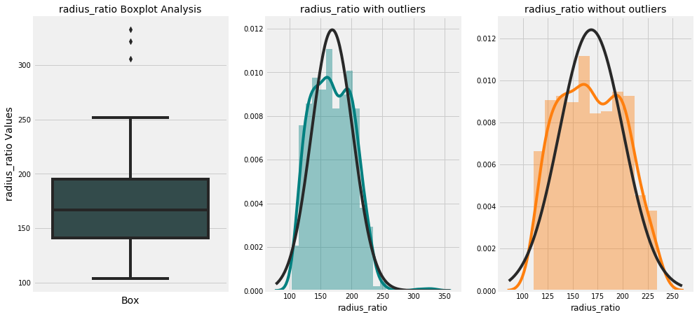

[output not shown]

```
Pr.axis_aspect_ratio column --------------------------------------------------------------------------------
```

|  | compactness | circularity | distance_circularity | radius_ratio | pr.axis_aspect_ratio | max.length_aspect_ratio | scatter_ratio | elongatedness | pr.axis_rectangularity | max.length_rectangularity | scaled_variance | scaled_variance.1 | scaled_radius_of_gyration | scaled_radius_of_gyration.1 | skewness_about | skewness_about.1 | skewness_about.2 | hollows_ratio | class |
| --- | --- | --- | --- | --- | --- | --- | --- | --- | --- | --- | --- | --- | --- | --- | --- | --- | --- | --- | --- |
| 4 | 85.00 | 44.00 | 70.00 | 205.00 | 103.00 | 52.00 | 149.00 | 45.00 | 19.00 | 144.00 | 241.00 | 325.00 | 188.00 | 127.00 | 9.00 | 11.00 | 180.00 | 183.00 | 2.00 |
| 37 | 90.00 | 48.00 | 86.00 | 306.00 | 126.00 | 49.00 | 153.00 | 44.00 | 19.00 | 156.00 | 272.00 | 346.00 | 200.00 | 118.00 | 0.00 | 15.00 | 185.00 | 194.00 | 1.00 |
| 100 | 82.00 | 45.00 | 66.00 | 252.00 | 126.00 | 52.00 | 148.00 | 45.00 | 19.00 | 144.00 | 237.00 | 326.00 | 185.00 | 119.00 | 1.00 | 1.00 | 181.00 | 185.00 | 2.00 |
| 135 | 89.00 | 47.00 | 83.00 | 322.00 | 133.00 | 48.00 | 158.00 | 43.00 | 20.00 | 163.00 | 229.00 | 364.00 | 176.00 | 97.00 | 0.00 | 14.00 | 184.00 | 194.00 | 1.00 |
| 291 | 89.00 | 45.00 | 81.00 | 246.00 | 102.00 | 43.00 | 155.00 | 44.00 | 20.00 | 160.00 | 200.00 | 347.00 | 177.00 | 90.00 | 9.00 | 17.00 | 183.00 | 192.00 | 1.00 |

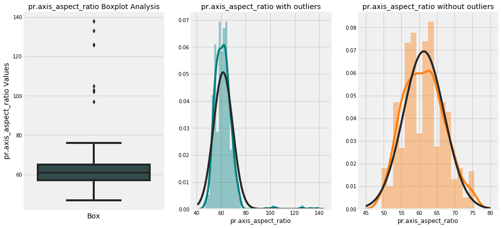

```
Max.length_aspect_ratio column --------------------------------------------------------------------------------
```

```
13
```

|  | compactness | circularity | distance_circularity | radius_ratio | pr.axis_aspect_ratio | max.length_aspect_ratio | scatter_ratio | elongatedness | pr.axis_rectangularity | max.length_rectangularity | scaled_variance | scaled_variance.1 | scaled_radius_of_gyration | scaled_radius_of_gyration.1 | skewness_about | skewness_about.1 | skewness_about.2 | hollows_ratio | class |
| --- | --- | --- | --- | --- | --- | --- | --- | --- | --- | --- | --- | --- | --- | --- | --- | --- | --- | --- | --- |
| 4 | 85.00 | 44.00 | 70.00 | 205.00 | 103.00 | 52.00 | 149.00 | 45.00 | 19.00 | 144.00 | 241.00 | 325.00 | 188.00 | 127.00 | 9.00 | 11.00 | 180.00 | 183.00 | 2.00 |
| 37 | 90.00 | 48.00 | 86.00 | 306.00 | 126.00 | 49.00 | 153.00 | 44.00 | 19.00 | 156.00 | 272.00 | 346.00 | 200.00 | 118.00 | 0.00 | 15.00 | 185.00 | 194.00 | 1.00 |
| 100 | 82.00 | 45.00 | 66.00 | 252.00 | 126.00 | 52.00 | 148.00 | 45.00 | 19.00 | 144.00 | 237.00 | 326.00 | 185.00 | 119.00 | 1.00 | 1.00 | 181.00 | 185.00 | 2.00 |
| 127 | 85.00 | 41.00 | 66.00 | 155.00 | 65.00 | 22.00 | 149.00 | 45.00 | 19.00 | 139.00 | 173.00 | 330.00 | 155.00 | 75.00 | 6.00 | 16.00 | 184.00 | 191.00 | 2.00 |
| 135 | 89.00 | 47.00 | 83.00 | 322.00 | 133.00 | 48.00 | 158.00 | 43.00 | 20.00 | 163.00 | 229.00 | 364.00 | 176.00 | 97.00 | 0.00 | 14.00 | 184.00 | 194.00 | 1.00 |

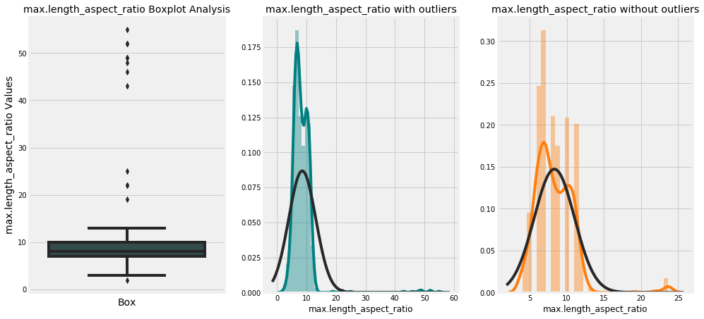

```
Scaled_variance column --------------------------------------------------------------------------------
```

```
1
```

|  | compactness | circularity | distance_circularity | radius_ratio | pr.axis_aspect_ratio | max.length_aspect_ratio | scatter_ratio | elongatedness | pr.axis_rectangularity | max.length_rectangularity | scaled_variance | scaled_variance.1 | scaled_radius_of_gyration | scaled_radius_of_gyration.1 | skewness_about | skewness_about.1 | skewness_about.2 | hollows_ratio | class |
| --- | --- | --- | --- | --- | --- | --- | --- | --- | --- | --- | --- | --- | --- | --- | --- | --- | --- | --- | --- |
| 388 | 94.00 | 47.00 | 85.00 | 333.00 | 138.00 | 49.00 | 155.00 | 43.00 | 19.00 | 155.00 | 320.00 | 354.00 | 187.00 | 135.00 | 12.00 | 9.00 | 188.00 | 196.00 | 1.00 |

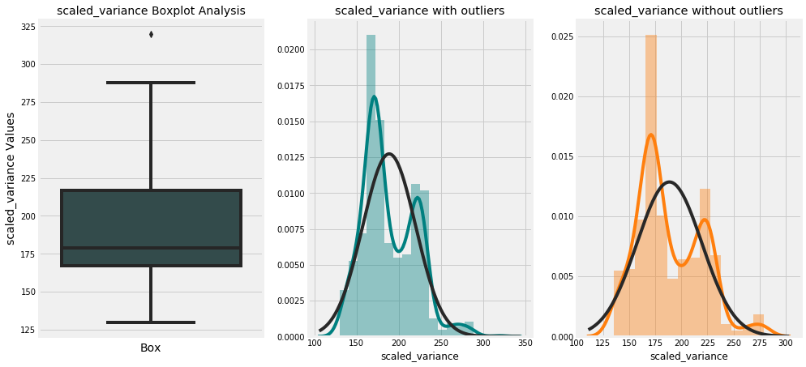

```
Scaled_variance.1 column --------------------------------------------------------------------------------
```

```
2
```

|  | compactness | circularity | distance_circularity | radius_ratio | pr.axis_aspect_ratio | max.length_aspect_ratio | scatter_ratio | elongatedness | pr.axis_rectangularity | max.length_rectangularity | scaled_variance | scaled_variance.1 | scaled_radius_of_gyration | scaled_radius_of_gyration.1 | skewness_about | skewness_about.1 | skewness_about.2 | hollows_ratio | class |
| --- | --- | --- | --- | --- | --- | --- | --- | --- | --- | --- | --- | --- | --- | --- | --- | --- | --- | --- | --- |
| 85 | 110.00 | 58.00 | 106.00 | 180.00 | 51.00 | 6.00 | 261.00 | 26.00 | 28.00 | 171.00 | 278.00 | 998.00 | 257.00 | 83.00 | 9.00 | 13.00 | 181.00 | 182.00 | 2.00 |
| 835 | 111.00 | 58.00 | 105.00 | 183.00 | 51.00 | 6.00 | 265.00 | 26.00 | 29.00 | 174.00 | 285.00 | 1018.00 | 255.00 | 85.00 | 4.00 | 8.00 | 181.00 | 183.00 | 2.00 |

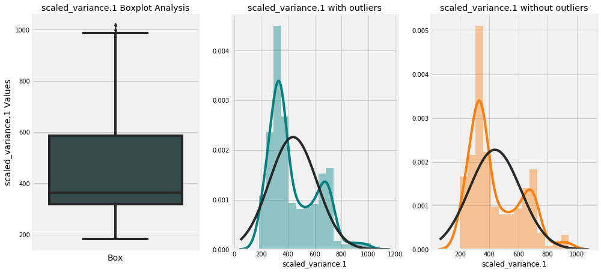

```
Scaled_radius_of_gyration.1 column --------------------------------------------------------------------------------
```

```
15
```

|  | compactness | circularity | distance_circularity | radius_ratio | pr.axis_aspect_ratio | max.length_aspect_ratio | scatter_ratio | elongatedness | pr.axis_rectangularity | max.length_rectangularity | scaled_variance | scaled_variance.1 | scaled_radius_of_gyration | scaled_radius_of_gyration.1 | skewness_about | skewness_about.1 | skewness_about.2 | hollows_ratio | class |
| --- | --- | --- | --- | --- | --- | --- | --- | --- | --- | --- | --- | --- | --- | --- | --- | --- | --- | --- | --- |
| 4 | 85.00 | 44.00 | 70.00 | 205.00 | 103.00 | 52.00 | 149.00 | 45.00 | 19.00 | 144.00 | 241.00 | 325.00 | 188.00 | 127.00 | 9.00 | 11.00 | 180.00 | 183.00 | 2.00 |
| 37 | 90.00 | 48.00 | 86.00 | 306.00 | 126.00 | 49.00 | 153.00 | 44.00 | 19.00 | 156.00 | 272.00 | 346.00 | 200.00 | 118.00 | 0.00 | 15.00 | 185.00 | 194.00 | 1.00 |
| 47 | 85.00 | 42.00 | 66.00 | 122.00 | 54.00 | 6.00 | 148.00 | 46.00 | 19.00 | 141.00 | 172.00 | 317.00 | 174.00 | 88.00 | 6.00 | 14.00 | 180.00 | 182.00 | 2.00 |
| 79 | 89.00 | 44.00 | 68.00 | 113.00 | 50.00 | 7.00 | 150.00 | 45.00 | 19.00 | 147.00 | 171.00 | 328.00 | 189.00 | 88.00 | 6.00 | 5.00 | 179.00 | 182.00 | 2.00 |
| 100 | 82.00 | 45.00 | 66.00 | 252.00 | 126.00 | 52.00 | 148.00 | 45.00 | 19.00 | 144.00 | 237.00 | 326.00 | 185.00 | 119.00 | 1.00 | 1.00 | 181.00 | 185.00 | 2.00 |

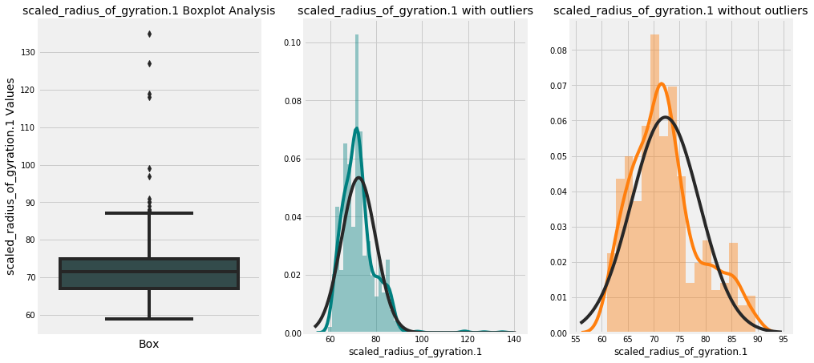

```
Skewness_about column --------------------------------------------------------------------------------
```

```
12
```

|  | compactness | circularity | distance_circularity | radius_ratio | pr.axis_aspect_ratio | max.length_aspect_ratio | scatter_ratio | elongatedness | pr.axis_rectangularity | max.length_rectangularity | scaled_variance | scaled_variance.1 | scaled_radius_of_gyration | scaled_radius_of_gyration.1 | skewness_about | skewness_about.1 | skewness_about.2 | hollows_ratio | class |
| --- | --- | --- | --- | --- | --- | --- | --- | --- | --- | --- | --- | --- | --- | --- | --- | --- | --- | --- | --- |
| 44 | 119.00 | 54.00 | 106.00 | 220.00 | 65.00 | 12.00 | 213.00 | 31.00 | 24.00 | 167.00 | 223.00 | 675.00 | 232.00 | 66.00 | 20.00 | 1.00 | 192.00 | 202.00 | 3.00 |
| 113 | 88.00 | 35.00 | 50.00 | 121.00 | 58.00 | 5.00 | 114.00 | 59.00 | 17.00 | 122.00 | 132.00 | 192.00 | 138.00 | 74.00 | 21.00 | 4.00 | 182.00 | 187.00 | 3.00 |
| 123 | 90.00 | 36.00 | 57.00 | 130.00 | 57.00 | 6.00 | 121.00 | 56.00 | 17.00 | 127.00 | 137.00 | 216.00 | 132.00 | 68.00 | 22.00 | 23.00 | 190.00 | 195.00 | 3.00 |
| 190 | 97.00 | 48.00 | 94.00 | 198.00 | 63.00 | 9.00 | 181.00 | 36.00 | 21.00 | 155.00 | 200.00 | 494.00 | 189.00 | 64.00 | 20.00 | 11.00 | 199.00 | 203.00 | 3.00 |
| 346 | 117.00 | 52.00 | 110.00 | 228.00 | 65.00 | 12.00 | 212.00 | 31.00 | 24.00 | 163.00 | 228.00 | 668.00 | 220.00 | 66.00 | 21.00 | 25.00 | 194.00 | 205.00 | 3.00 |

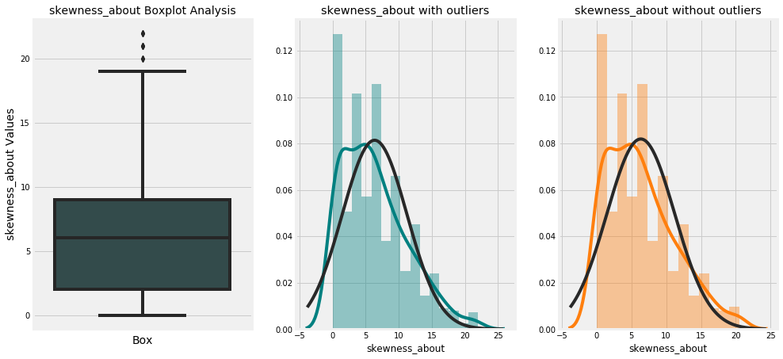

```
Skewness_about.1 column --------------------------------------------------------------------------------
```

```
1
```

|  | compactness | circularity | distance_circularity | radius_ratio | pr.axis_aspect_ratio | max.length_aspect_ratio | scatter_ratio | elongatedness | pr.axis_rectangularity | max.length_rectangularity | scaled_variance | scaled_variance.1 | scaled_radius_of_gyration | scaled_radius_of_gyration.1 | skewness_about | skewness_about.1 | skewness_about.2 | hollows_ratio | class |
| --- | --- | --- | --- | --- | --- | --- | --- | --- | --- | --- | --- | --- | --- | --- | --- | --- | --- | --- | --- |
| 132 | 97.00 | 42.00 | 101.00 | 186.00 | 59.00 | 9.00 | 186.00 | 36.00 | 22.00 | 138.00 | 208.00 | 511.00 | 168.00 | 67.00 | 7.00 | 41.00 | 194.00 | 206.00 | 3.00 |

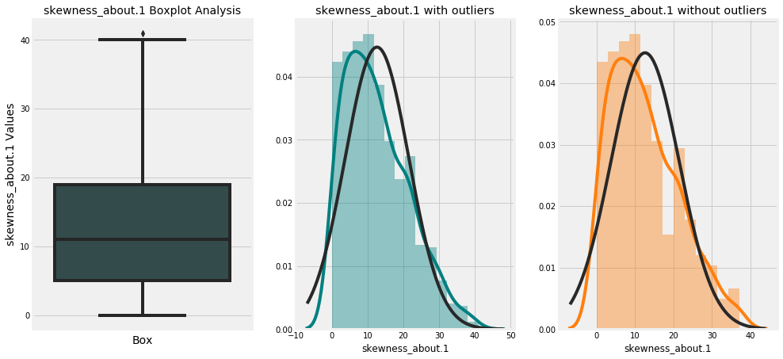

```python
# Outlier distribution for columns with outliers
boxplot_column = ['radius_ratio', 'pr.axis_aspect_ratio', 'max.length_aspect_ratio', 'scaled_variance', 'scaled_variance.1',
                  'scaled_radius_of_gyration.1', 'skewness_about', 'skewness_about.1']
for col in boxplot_column:
    Q3 = vehicle[col].quantile(0.75)
    Q1 = vehicle[col].quantile(0.25)
    IQR = Q3 - Q1

    print(f'{col.capitalize()} column', '--'*40)
    display(len(vehicle.loc[(vehicle[col] < (Q1 - 1.5 * IQR)) | (vehicle[col] > (Q3 + 1.5 * IQR))]),
            vehicle.loc[(vehicle[col] < (Q1 - 1.5 * IQR)) | (vehicle[col] > (Q3 + 1.5 * IQR))].head())
    odp_plots(vehicle, col)

del col, IQR, boxplot_column
```

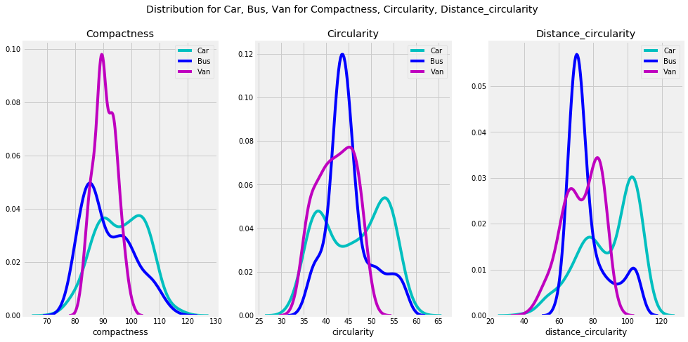

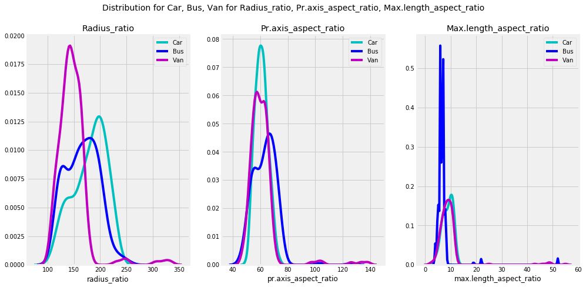

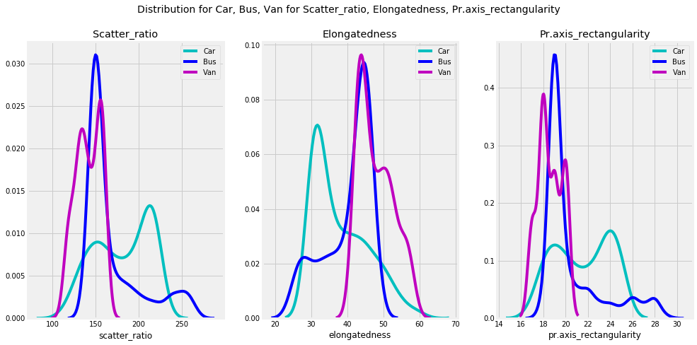

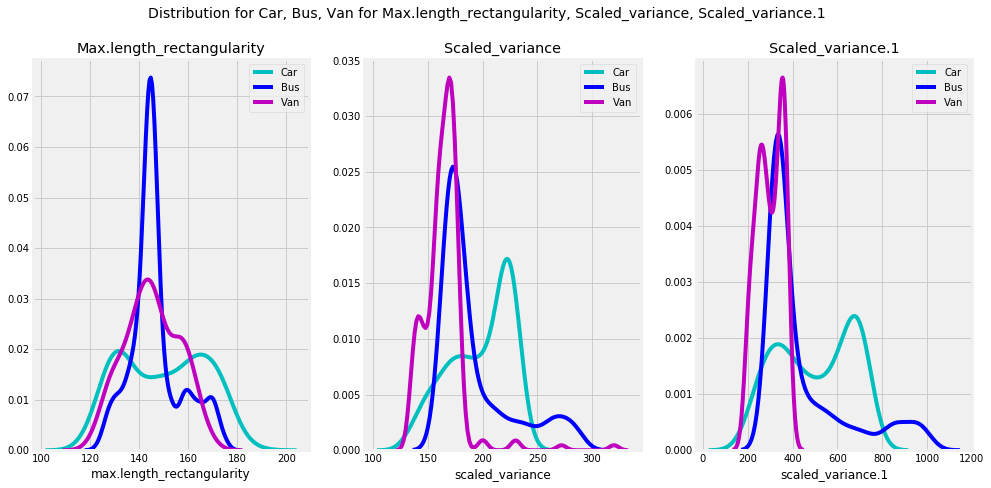

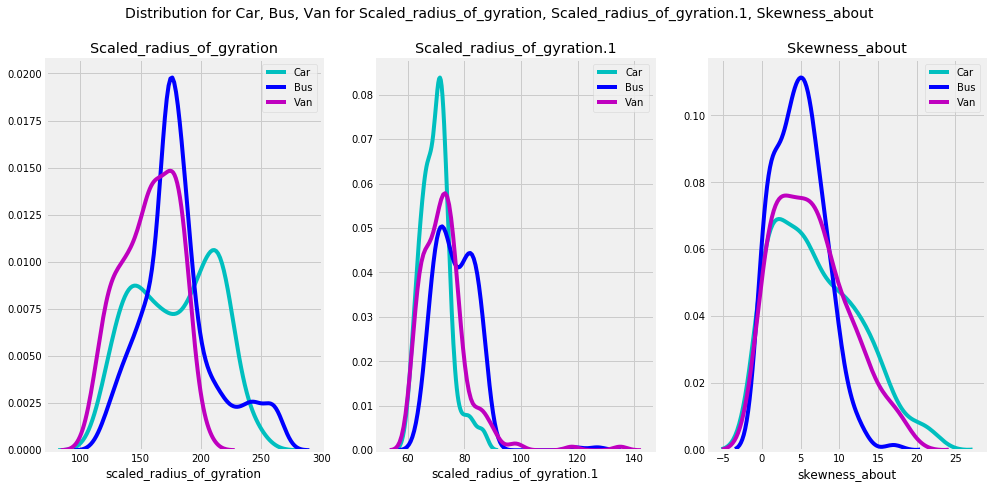

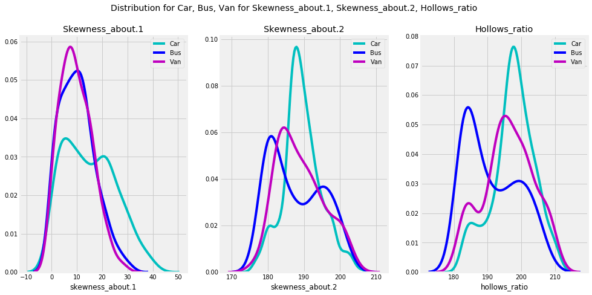

```python
# Target column distribution
target_plot(vehicle, 'compactness', 'circularity', 'distance_circularity')
target_plot(vehicle, 'radius_ratio', 'pr.axis_aspect_ratio', 'max.length_aspect_ratio')
target_plot(vehicle, 'scatter_ratio', 'elongatedness', 'pr.axis_rectangularity')
target_plot(vehicle, 'max.length_rectangularity', 'scaled_variance', 'scaled_variance.1')
target_plot(vehicle, 'scaled_radius_of_gyration', 'scaled_radius_of_gyration.1', 'skewness_about')
target_plot(vehicle, 'skewness_about.1', 'skewness_about.2', 'hollows_ratio')
```

```python
#Handling outliers using SimpleImputer
vehicle_out = vehicle.copy(deep = True)
outliers_col = ['radius_ratio', 'pr.axis_aspect_ratio', 'max.length_aspect_ratio', 'scaled_variance', 'scaled_variance.1',
           'scaled_radius_of_gyration.1', 'skewness_about', 'skewness_about.1']

for col in outliers_col:
    Q3 = vehicle_out[col].quantile(0.75)
    Q1 = vehicle_out[col].quantile(0.25)
    IQR = Q3 - Q1
    upper_lim = Q3 + (1.5 * IQR)
    lower_lim = Q1 - (1.5 * IQR)
    vehicle_out.loc[(vehicle_out[col] < lower_lim) | (vehicle_out[col] > upper_lim), col] = np.nan

print('Column for which outliers where removed with upper and lower percentile values: \n', outliers_col)
```

```
Column for which outliers where removed with upper and lower percentile values:
 ['radius_ratio', 'pr.axis_aspect_ratio', 'max.length_aspect_ratio', 'scaled_variance', 'scaled_variance.1', 'scaled_radius_of_gyration.1', 'skewness_about', 'skewness_about.1']
```

```python
vehicle_out.isnull().sum()
```

```
compactness                     0
circularity                     0
distance_circularity            0
radius_ratio                    3
pr.axis_aspect_ratio            8
max.length_aspect_ratio        13
scatter_ratio                   0
elongatedness                   0
pr.axis_rectangularity          0
max.length_rectangularity       0
scaled_variance                 1
scaled_variance.1               2
scaled_radius_of_gyration       0
scaled_radius_of_gyration.1    15
skewness_about                 12
skewness_about.1                1
skewness_about.2                0
hollows_ratio                   0
class                           0
dtype: int64
```

```python
# Using SimpleImputer to fill missing values by median
print('Descriptive Statistics before handling outliers: \n', '--'*30)
display(vehicle[outliers_col].describe().T)

columns = list(vehicle_out.columns)
impute = SimpleImputer(missing_values = np.nan, strategy = 'median', verbose = 1)
vehicle_out = pd.DataFrame(impute.fit_transform(vehicle_out), columns = columns)

print('Descriptive Statistics after handling outliers: \n', '--'*30)
display(vehicle_out[outliers_col].describe().T)
del outliers_col, vehicle
```

```
Descriptive Statistics before handling outliers:
 ------------------------------------------------------------
```

|  | count | mean | std | min | 25% | 50% | 75% | max |
| --- | --- | --- | --- | --- | --- | --- | --- | --- |
| radius_ratio | 846.00 | 168.87 | 33.40 | 104.00 | 141.00 | 167.00 | 195.00 | 333.00 |
| pr.axis_aspect_ratio | 846.00 | 61.68 | 7.88 | 47.00 | 57.00 | 61.00 | 65.00 | 138.00 |
| max.length_aspect_ratio | 846.00 | 8.57 | 4.60 | 2.00 | 7.00 | 8.00 | 10.00 | 55.00 |
| scaled_variance | 846.00 | 188.60 | 31.36 | 130.00 | 167.00 | 179.00 | 217.00 | 320.00 |
| scaled_variance.1 | 846.00 | 439.31 | 176.50 | 184.00 | 318.25 | 363.50 | 586.75 | 1018.00 |
| scaled_radius_of_gyration.1 | 846.00 | 72.44 | 7.47 | 59.00 | 67.00 | 71.50 | 75.00 | 135.00 |
| skewness_about | 846.00 | 6.36 | 4.90 | 0.00 | 2.00 | 6.00 | 9.00 | 22.00 |
| skewness_about.1 | 846.00 | 12.60 | 8.93 | 0.00 | 5.00 | 11.00 | 19.00 | 41.00 |

```
Descriptive Statistics after handling outliers:
 ------------------------------------------------------------
```

|  | count | mean | std | min | 25% | 50% | 75% | max |
| --- | --- | --- | --- | --- | --- | --- | --- | --- |
| radius_ratio | 846.00 | 168.33 | 32.15 | 104.00 | 141.00 | 167.00 | 194.75 | 252.00 |
| pr.axis_aspect_ratio | 846.00 | 61.15 | 5.61 | 47.00 | 57.00 | 61.00 | 65.00 | 76.00 |
| max.length_aspect_ratio | 846.00 | 8.12 | 2.06 | 3.00 | 7.00 | 8.00 | 10.00 | 13.00 |
| scaled_variance | 846.00 | 188.43 | 31.03 | 130.00 | 167.00 | 179.00 | 216.75 | 288.00 |
| scaled_variance.1 | 846.00 | 437.79 | 174.35 | 184.00 | 318.25 | 363.25 | 586.00 | 987.00 |
| scaled_radius_of_gyration.1 | 846.00 | 71.93 | 6.16 | 59.00 | 67.00 | 71.00 | 75.00 | 87.00 |
| skewness_about | 846.00 | 6.13 | 4.57 | 0.00 | 2.00 | 5.00 | 9.00 | 19.00 |
| skewness_about.1 | 846.00 | 12.57 | 8.88 | 0.00 | 5.00 | 11.00 | 19.00 | 40.00 |

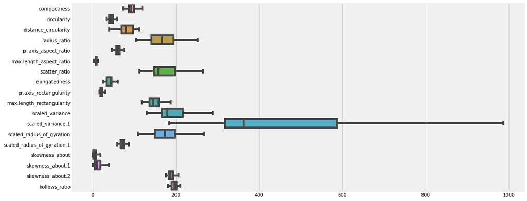

```python
#Checking columns that contain outliers
fig = plt.figure(figsize = (15, 7.2))
ax = sns.boxplot(data = vehicle_out.iloc[:, 0:18], orient = 'h')
```

Despite removing the outliers, which led to Data loss, first replace the outliers (using IQR method) with Null values and then used SimpleImputer method to replace those nulls with median values.

# Multivariate Visualization

```
scatter_ratio                pr.axis_rectangularity        0.99
pr.axis_rectangularity       scatter_ratio                 0.99
scaled_variance.1            scatter_ratio                 0.98
scatter_ratio                scaled_variance.1             0.98
pr.axis_rectangularity       scaled_variance.1             0.97
scaled_variance.1            pr.axis_rectangularity        0.97
scatter_ratio                elongatedness                 0.97
elongatedness                scatter_ratio                 0.97
max.length_rectangularity    circularity                   0.96
circularity                  max.length_rectangularity     0.96
scaled_variance              scatter_ratio                 0.96
scatter_ratio                scaled_variance               0.96
elongatedness                pr.axis_rectangularity        0.95
pr.axis_rectangularity       elongatedness                 0.95
elongatedness                scaled_variance.1             0.95
scaled_variance.1            elongatedness                 0.95
scaled_variance              elongatedness                 0.95
elongatedness                scaled_variance               0.95
pr.axis_rectangularity       scaled_variance               0.95
scaled_variance              pr.axis_rectangularity        0.95
                             scaled_variance.1             0.94
scaled_variance.1            scaled_variance               0.94
circularity                  scaled_radius_of_gyration     0.93
scaled_radius_of_gyration    circularity                   0.93
distance_circularity         elongatedness                 0.91
elongatedness                distance_circularity          0.91
scatter_ratio                distance_circularity          0.91
distance_circularity         scatter_ratio                 0.91
scaled_radius_of_gyration.1  hollows_ratio                 0.90
hollows_ratio                scaled_radius_of_gyration.1   0.90
pr.axis_rectangularity       distance_circularity          0.89
distance_circularity         pr.axis_rectangularity        0.89
skewness_about.2             hollows_ratio                 0.89
hollows_ratio                skewness_about.2              0.89
scaled_variance.1            distance_circularity          0.88
distance_circularity         scaled_variance.1             0.88
                             scaled_variance               0.87
scaled_variance              distance_circularity          0.87
max.length_rectangularity    scaled_radius_of_gyration     0.87
scaled_radius_of_gyration    max.length_rectangularity     0.87
```

[output cut: 10 more lines]

```
elongatedness                circularity                   0.82
circularity                  elongatedness                 0.82
pr.axis_rectangularity       compactness                   0.81
compactness                  pr.axis_rectangularity        0.81
scatter_ratio                compactness                   0.81
compactness                  scatter_ratio                 0.81
pr.axis_rectangularity       max.length_rectangularity     0.81
max.length_rectangularity    pr.axis_rectangularity        0.81
                             scatter_ratio                 0.81
scatter_ratio                max.length_rectangularity     0.81
scaled_variance.1            compactness                   0.81
compactness                  scaled_variance.1             0.81
circularity                  scaled_variance               0.80
scaled_variance              circularity                   0.80
dtype: float64
```

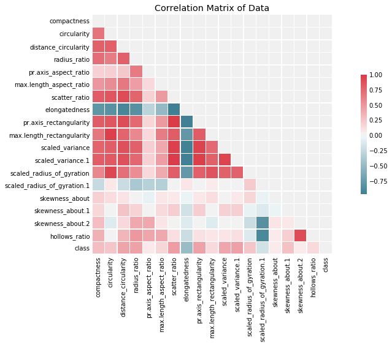

```python
# Correlation matrix for all variables
correlation_matrix(vehicle_out, threshold = 0.8)
```

```python
# Absolute correlation of independent variables with the target column
absCorrwithtar = []
allVar = vehicle_out.drop('class', axis = 1).columns

for var in allVar:
    absCorrwithtar.append(abs(vehicle_out['class'].corr(vehicle_out[var])))

display(pd.DataFrame([allVar, absCorrwithtar], index = ['Variable', 'Correlation']).T.\
        sort_values('Correlation', ascending = False))
```

|  | Variable | Correlation |
| --- | --- | --- |
| 7 | elongatedness | 0.48 |
| 6 | scatter_ratio | 0.46 |
| 11 | scaled_variance.1 | 0.45 |
| 8 | pr.axis_rectangularity | 0.44 |
| 3 | radius_ratio | 0.44 |
| 2 | distance_circularity | 0.43 |
| 10 | scaled_variance | 0.42 |
| 0 | compactness | 0.30 |
| 15 | skewness_about.1 | 0.27 |
| 1 | circularity | 0.25 |
| 12 | scaled_radius_of_gyration | 0.25 |
| 13 | scaled_radius_of_gyration.1 | 0.18 |
| 5 | max.length_aspect_ratio | 0.17 |
| 17 | hollows_ratio | 0.14 |
| 9 | max.length_rectangularity | 0.14 |
| 4 | pr.axis_aspect_ratio | 0.06 |
| 14 | skewness_about | 0.06 |
| 16 | skewness_about.2 | 0.05 |

elongatedness, scatter_ratio, scaled_variance.1, pr.axis_rectangularity and radius_ratio are some features which have relatively strong correlation with the target column (class)

Eventhough multicollinearity exists between columns, some of those have a strong influence on the target column as well.

```python
# Removing max.length_rectangularity, scaled_variance, scaled_radius_of_gyration, distance_circularity, hollows_ratio and skewness_about.2

vehicle_out.drop(['max.length_rectangularity', 'scaled_variance', 'scaled_radius_of_gyration',
                 'distance_circularity', 'hollows_ratio', 'skewness_about.2'], axis = 1, inplace = True)
```

```
Highly correlated variables ----------------------------------------
```

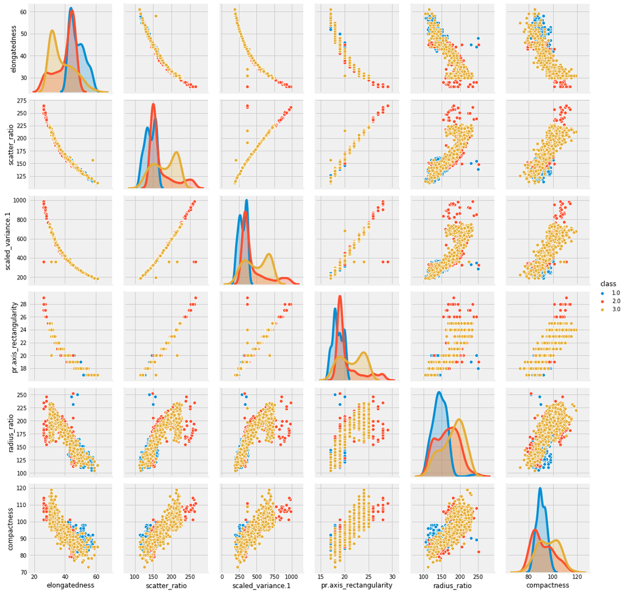

```python
print('Highly correlated variables', '--'*20)
sns.pairplot(vehicle_out[['elongatedness', 'scatter_ratio', 'scaled_variance.1',
             'pr.axis_rectangularity', 'radius_ratio', 'compactness', 'class']], hue = 'class');
```

```python
# Creating features and target column
features = vehicle_out.iloc[:, 0:12];
features_list = list(features.columns)
target = vehicle_out['class']

features.shape, target.shape
```

```
((846, 12), (846,))
```

```python
features.head()
```

|  | compactness | circularity | radius_ratio | pr.axis_aspect_ratio | max.length_aspect_ratio | scatter_ratio | elongatedness | pr.axis_rectangularity | scaled_variance.1 | scaled_radius_of_gyration.1 | skewness_about | skewness_about.1 |
| --- | --- | --- | --- | --- | --- | --- | --- | --- | --- | --- | --- | --- |
| 0 | 95.00 | 48.00 | 178.00 | 72.00 | 10.00 | 162.00 | 42.00 | 20.00 | 379.00 | 70.00 | 6.00 | 16.00 |
| 1 | 91.00 | 41.00 | 141.00 | 57.00 | 9.00 | 149.00 | 45.00 | 19.00 | 330.00 | 72.00 | 9.00 | 14.00 |
| 2 | 104.00 | 50.00 | 209.00 | 66.00 | 10.00 | 207.00 | 32.00 | 23.00 | 635.00 | 73.00 | 14.00 | 9.00 |
| 3 | 93.00 | 41.00 | 159.00 | 63.00 | 9.00 | 144.00 | 46.00 | 19.00 | 309.00 | 63.00 | 6.00 | 10.00 |
| 4 | 85.00 | 44.00 | 205.00 | 61.00 | 8.00 | 149.00 | 45.00 | 19.00 | 325.00 | 71.00 | 9.00 | 11.00 |

# 3. Split the data into train and test

```python
# Splitting the data into training and test set in the ratio of 70:30 respectively before scaling
X_train, X_test, y_train, y_test = train_test_split(features, target, test_size = 0.30,
                                                    random_state = random_state, shuffle = False)
```

```python
#Apply Feature Scaling technique to standardize the independent features in fixed range
X_train = StandardScaler().fit_transform(X_train)
X_test = StandardScaler().fit_transform(X_test)
y_train = y_train.values
y_test = y_test.values
display(X_train.shape, y_train.shape, X_test.shape, y_test.shape)
```

```
(592, 12)
```

```
(592,)
```

```
(254, 12)
```

```
(254,)
```

```python
#Display Target column's Test data
pd.crosstab(y_test,columns='count',colnames=['class'])
```

| class row_0 | count |
| --- | --- |
| 1.00 | 59 |
| 2.00 | 62 |
| 3.00 | 133 |

```python
#check split of dataset
print("{0:0.2f}% data is in training set".format((len(X_train)/len(vehicle_out.index)) * 100))
print("{0:0.2f}% data is in test set".format((len(X_test)/len(vehicle_out.index)) * 100))
```

```
69.98% data is in training set
30.02% data is in test set
```

# 4. Train a Support vector machine using the train set and get the accuracy on the test set

5 .Perform K-fold cross validation and get the cross validation score of the model

```
SVC Model with Hyperparameter Tuning using Raw data


Best Hyper Parameters are:  {'C': 1, 'kernel': 'rbf'}
Best Score is:  0.934
SVC accuracy score for train set: 0.951
SVC accuracy score for test set: 0.929
SVC cross validation score:  0.936

Accuracy Score:
 0.929

              precision    recall  f1-score   support

         1.0       0.90      0.88      0.89        59
         2.0       0.92      0.97      0.94        62
         3.0       0.95      0.93      0.94       133

    accuracy                           0.93       254
   macro avg       0.92      0.93      0.92       254
weighted avg       0.93      0.93      0.93       254
```

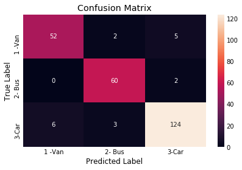

|  | SVM_Raw |
| --- | --- |
| Accuracy score | 0.93 |
| Cross Validation score | 0.936 |

```python
# Build SVC Model  with hyperparameter tuning using Original Dataset
svc_raw = SVC(random_state = random_state)

params_raw = {'C': [0.01, 0.05, 0.5, 1], 'kernel': ['linear', 'rbf']}

skf_raw = StratifiedKFold(n_splits = 10)
grid_svc_f_raw = GridSearchCV(svc_raw, param_grid = params_raw, n_jobs = -1, cv = skf_raw)

grid_svc_f_raw.fit(X_train, y_train)

print('SVC Model with Hyperparameter Tuning using Raw data\n\n')
print('Best Hyper Parameters are: ', grid_svc_f_raw.best_params_)
print('Best Score is: ', grid_svc_f_raw.best_score_.round(3))

print('SVC accuracy score for train set: {0:.3f}'.format(grid_svc_f_raw.score(X_train, y_train)))
print('SVC accuracy score for test set: {0:.3f}'.format(grid_svc_f_raw.score(X_test, y_test)))

y_true, y_pred = y_test, grid_svc_f_raw.predict(X_test)

# Cross Validation Score
Best_scoring = 'accuracy'
grid_svc_f_score_raw = cross_val_score(grid_svc_f_raw, X_train, y_train, cv = skf_raw, scoring = Best_scoring)
print('SVC cross validation score: ', round(grid_svc_f_score_raw.mean(), 3).astype(str))

# Accuracy Score
acc_raw = accuracy_score(y_true, y_pred)
print('\nAccuracy Score:\n', acc_raw.round(3))

# Classification Report
print('\n{}'.format(classification_report(y_true, y_pred)))

# Confusion Matrix
cm_raw = confusion_matrix(y_true, y_pred)
label = ["1 -Van", "2- Bus", "3-Car"]
cm1_raw = pd.DataFrame(cm_raw, index = label, columns = label)
sns.heatmap(cm1_raw, annot = True, fmt = "d")
plt.title("Confusion Matrix")
plt.xlabel("Predicted Label")
plt.ylabel("True Label")
plt.show()

#Store the accuracy score results of SVM using Original data with Principal components for final comparison
data_raw=[acc_raw.round(3),round(grid_svc_f_score_raw.mean(), 3).astype(str)]
rawdf = pd.DataFrame(data_raw ,index= ['Accuracy score','Cross Validation score'] ,columns =['SVM_Raw'])
rawdf
```

# 6. Use PCA from Scikit learn, extract Principal Components that capture about 95% of the variance in the data

```python
#Creating a covariance matrix to identify Principal components
cov_matrix = np.cov(X_train.T)
print('Covariance Matrix \n%s', cov_matrix)
```

```
Covariance Matrix
%s [[ 1.00169205  0.69023741  0.72681237  0.1878761   0.48013019  0.81453295
  -0.79049475  0.81614423  0.80910132 -0.24307066  0.19428084  0.15732133]
 [ 0.69023741  1.00169205  0.6463648   0.19968041  0.54597259  0.8499822
  -0.82806937  0.8442233   0.82997516  0.06195212  0.11646635  0.00350215]
 [ 0.72681237  0.6463648   1.00169205  0.63637818  0.45052176  0.76997464
  -0.82424476  0.74614184  0.75729383 -0.39119662  0.02940335  0.19718839]
 [ 0.1878761   0.19968041  0.63637818  1.00169205  0.13334727  0.17871841
  -0.27793844  0.15131984  0.17704554 -0.32158172 -0.07298964 -0.01974765]
 [ 0.48013019  0.54597259  0.45052176  0.13334727  1.00169205  0.4756332
  -0.49241611  0.47113137  0.4418424  -0.33855238  0.09883599  0.16411842]
 [ 0.81453295  0.8499822   0.76997464  0.17871841  0.4756332   1.00169205
  -0.97320354  0.99041662  0.98481284  0.01062452  0.05438725  0.21748916]
 [-0.79049475 -0.82806937 -0.82424476 -0.27793844 -0.49241611 -0.97320354
   1.00169205 -0.9510652  -0.95170555  0.07674523 -0.03628674 -0.19304253]
 [ 0.81614423  0.8442233   0.74614184  0.15131984  0.47113137  0.99041662
  -0.9510652   1.00169205  0.97900577  0.02684421  0.06455006  0.21828021]
 [ 0.80910132  0.82997516  0.75729383  0.17704554  0.4418424   0.98481284
  -0.95170555  0.97900577  1.00169205  0.01675199  0.05222795  0.20360899]
 [-0.24307066  0.06195212 -0.39119662 -0.32158172 -0.33855238  0.01062452
   0.07674523  0.02684421  0.01675199  1.00169205 -0.08291357 -0.16225202]
 [ 0.19428084  0.11646635  0.02940335 -0.07298964  0.09883599  0.05438725
  -0.03628674  0.06455006  0.05222795 -0.08291357  1.00169205 -0.02924543]
 [ 0.15732133  0.00350215  0.19718839 -0.01974765  0.16411842  0.21748916
  -0.19304253  0.21828021  0.20360899 -0.16225202 -0.02924543  1.00169205]]
```

```python
#Find Eigen Values and vectors
eig_vals, eig_vecs = np.linalg.eig(cov_matrix)
print('Eigen Vectors \n%s', eig_vecs)
print('\n Eigen Values \n%s', eig_vals)
```

```
Eigen Vectors
%s [[-3.40513057e-01 -2.39161092e-02  1.56402222e-01  6.15307541e-02
   2.44392113e-02  3.92040184e-01 -7.97531058e-01  2.17796401e-01
  -1.00874323e-02 -3.15408123e-02 -1.27774532e-01  4.94340631e-03]
 [-3.40567784e-01  1.71985666e-01 -2.80030507e-02  1.83038173e-01
  -1.60987309e-01 -2.40739297e-01  2.52936107e-01  8.14820940e-01
  -2.11329557e-02 -3.80250491e-02 -1.59151912e-02  7.88632367e-02]
 [-3.39055878e-01 -3.06930247e-01 -1.67340407e-01  4.73623994e-02
   1.68172126e-01  3.39097368e-02  7.95395826e-02 -1.50899747e-01
  -1.38117133e-02 -1.97093700e-02  1.98955244e-01  8.13570834e-01]
 [-1.25585631e-01 -5.23550282e-01 -4.51130009e-01  2.32788215e-01
   3.10841886e-01 -4.19890270e-01 -1.92409808e-01  2.52233185e-02
   1.91976432e-02  3.22609966e-02 -1.62935382e-02 -3.74368330e-01]
 [-2.30718599e-01 -1.88579572e-01  3.07713390e-01 -2.06320169e-02
  -6.81579111e-01 -4.95062840e-01 -1.79267746e-01 -2.68792186e-01
   2.46863742e-04 -2.36426807e-02  3.48033190e-02  1.73115668e-02]
 [-3.80422352e-01  1.59474282e-01 -3.57495326e-02 -5.43536883e-02
   4.35246349e-02  6.15113527e-02  1.20702216e-01 -1.49846832e-01
   8.59316179e-01  1.63778907e-01 -1.11206711e-02 -1.32445465e-01]
 [ 3.79558250e-01 -6.68719585e-02  7.86048900e-02  2.31578550e-02
  -3.55815601e-02 -4.90527684e-02 -2.36505133e-01  2.45664670e-01
   2.64141208e-01  9.65612895e-02  8.02728164e-01  3.63794603e-02]
 [-3.76555642e-01  1.78597494e-01 -1.71910712e-02 -5.70706838e-02
   4.13503587e-02  6.81936067e-02  7.20065060e-02 -1.29072760e-01
  -4.03721896e-01  6.98866689e-01  3.20839218e-01 -2.00517907e-01]
 [-3.75009600e-01  1.66040305e-01 -4.72304895e-02 -4.72731836e-02
   6.72658603e-02  1.00678425e-01  1.03881244e-01 -1.71849598e-01
  -1.64997929e-01 -6.85218149e-01  4.39221795e-01 -2.87549112e-01]
 [ 6.16133114e-02  6.78329826e-01 -2.50687732e-01  3.27261996e-02
   1.87633196e-01 -4.83113296e-01 -3.58816829e-01 -1.51740399e-01
  -1.80225144e-02 -3.14757929e-02 -2.98774693e-02  2.22642238e-01]
 [-3.82458701e-02  8.17863079e-03  7.08332908e-01  4.77574382e-01
   4.65584958e-01 -1.88776592e-01  8.86140577e-02 -9.11852988e-02
   1.88275494e-03 -2.20064139e-03 -1.22137501e-03 -8.63250121e-03]
 [-8.73601833e-02 -1.28089911e-01  2.71997591e-01 -8.17141996e-01
   3.50229391e-01 -2.75304864e-01 -3.74247643e-02  1.80660460e-01
  -1.23835757e-02 -2.21206565e-02 -3.34143236e-02  2.45748236e-03]]

 Eigen Values
%s [6.50125326e+00 1.58104044e+00 1.12875491e+00 1.05795383e+00
 7.54543185e-01 5.05146766e-01 2.03213373e-01 1.54019624e-01
 6.18425394e-03 2.14174039e-02 4.17937969e-02 6.49837218e-02]
```

```python
#Find variance and cumulative variance in each eigen vector
total = sum(eig_vals)
var_exp = [(i /total) * 100 for i in sorted(eig_vals, reverse = True)]
cum_var_exp = np.cumsum(var_exp)

print('Cumulative Variance Explained', cum_var_exp)
```

```
Cumulative Variance Explained [ 54.08559513  67.23867646  76.6290784   85.43046797  91.70770645
  95.9101521   97.60073633  98.88206513  99.42268139  99.77037472
  99.9485516  100.        ]
```

```python
tot = sum(eig_vals)
var_exp = [(i /tot) * 100 for i in sorted(eig_vals, reverse = True)]
cum_var_exp = np.cumsum(var_exp)

print('Cumulative Variance Explained', cum_var_exp)
```

```
Cumulative Variance Explained [ 54.08559513  67.23867646  76.6290784   85.43046797  91.70770645
  95.9101521   97.60073633  98.88206513  99.42268139  99.77037472
  99.9485516  100.        ]
```

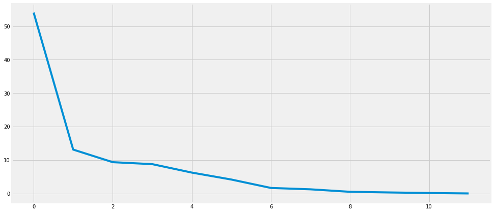

```python
#Plotting the Percentage of variation explained in each eigen value
plt.figure(figsize = (15 , 7.2))
plt.plot(var_exp)
```

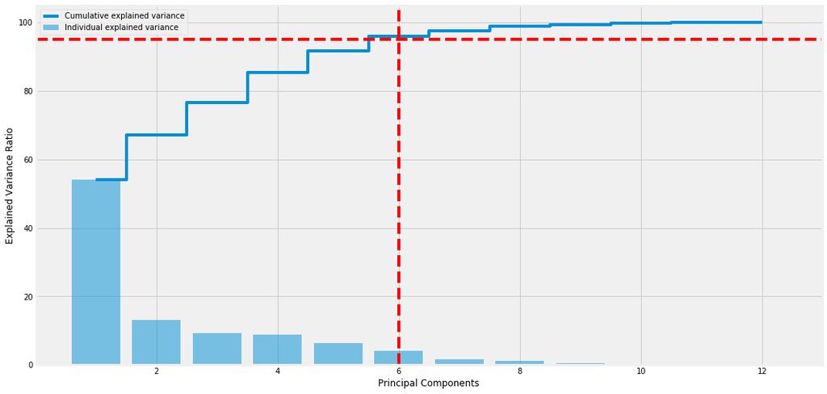

```python
#Identify the Principal components
plt.figure(figsize = (15 , 7.2))
plt.bar(range(1, eig_vals.size + 1), var_exp, alpha = 0.5, align = 'center', label = 'Individual explained variance')
plt.step(range(1, eig_vals.size + 1), cum_var_exp, where = 'mid', label = 'Cumulative explained variance')
plt.axhline(y = 95, color = 'r', linestyle = '--')
plt.axvline(x = 6, color = 'r', linestyle = '--')
plt.ylabel('Explained Variance Ratio')
plt.xlabel('Principal Components')
plt.legend(loc = 'best')
plt.tight_layout()
plt.show()
```

From the above plot, high decrease in variance explained with increase in number of Principal components.

Only six principal components covers more than 95% of variance.

# 7. Repeat steps 3,4 and 5 but this time, use Principal Components instead of the original data. And the accuracy score should be on the same rows of test data that were used earlier

```python
#Split the dataset after Dimensionality Reduction into train and test set with Principal Components
pca = PCA(n_components = 6, random_state = random_state)
pca.fit(X_train)
X_train_min = pca.fit_transform(X_train)
X_test_min = pca.fit_transform(X_test)
display(X_train_min.shape, X_test_min.shape)
```

```
(592, 6)
```

```
(254, 6)
```

```python
#Eigen Values
print(pca.explained_variance_)
```

```
[6.59525476 1.56482081 1.1274292  0.96015738 0.83850168 0.49583913]
```

```python
#Eigen vectors
print(pca.components_)
```

```
[[ 0.33741485  0.33569213  0.33793241  0.14610024  0.25188697  0.37785344
  -0.37672812  0.37344256  0.37339694 -0.05961435  0.04826319  0.07075493]
 [-0.01086206  0.18882104 -0.32264571 -0.54478423 -0.15334098  0.15770086
  -0.04910712  0.18334131  0.13956454  0.66498934  0.12693032  0.03360906]
 [ 0.04436559  0.20305068 -0.00657044  0.09189558  0.03635989 -0.05985334
   0.03731283 -0.06225732 -0.06189887 -0.01301911  0.63199315 -0.73124903]
 [ 0.22093805 -0.12086877 -0.10995014 -0.35673502  0.21333815 -0.05592639
   0.09514586 -0.03401913 -0.03802584 -0.36103305  0.60452657  0.49105403]
 [-0.08627029 -0.12890372  0.20358816  0.47481033 -0.57680954  0.02708008
  -0.05742478  0.00436329  0.04666755  0.26987989  0.42517606  0.34132296]
 [ 0.34992557 -0.25515532  0.07182528 -0.35121712 -0.64802783  0.1040775
  -0.10598432  0.10280796  0.11217313 -0.37270413 -0.11999631 -0.25587278]]
```

```python
#Percentage of variation explained by each eigen Value
print(pca.explained_variance_ratio_)
```

```
[0.54744077 0.12988834 0.09358254 0.0796981  0.06960004 0.04115725]
```

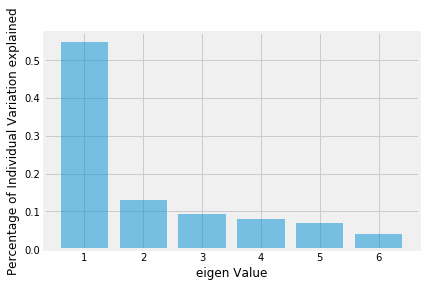

```python
plt.bar(list(range(1,7)),pca.explained_variance_ratio_,alpha=0.5, align='center')
plt.ylabel('Percentage of Individual Variation explained')
plt.xlabel('eigen Value')
plt.show()
```

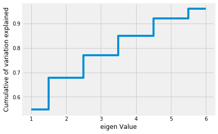

```python
plt.step(list(range(1,7)),np.cumsum(pca.explained_variance_ratio_), where='mid')
plt.ylabel('Cumulative of variation explained')
plt.xlabel('eigen Value')
plt.show()
```

# Dimensionality Reduction

dimensionality reduction using PCA technique, attributes have became independent with no correlation between them to avoid multi-collinearity.

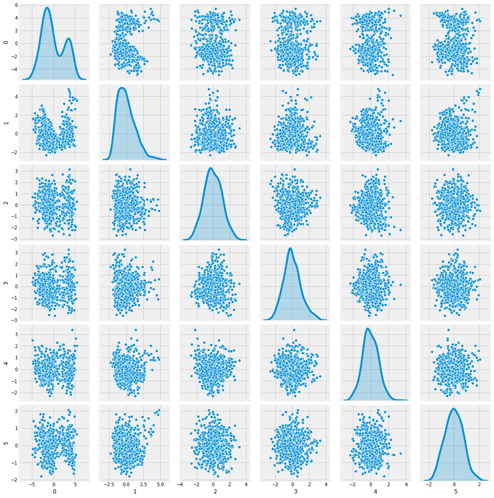

```python
# Pairplot after dimension reduction
sns.pairplot(pd.DataFrame(X_train_min), diag_kind = 'kde');
```

```python
# Creating Vehicle Dataframe after Dimensionality Reduction using PCA technique with features and target column
vehicle_train= pd.DataFrame(X_train_min).join(pd.DataFrame(y_train, columns = ['class']), how = 'left', sort = False)
vehicle_test = pd.DataFrame(X_test_min).join(pd.DataFrame(y_test, columns = ['class']), how = 'left', sort = False)
print ("Dimension of Train and test Dataset after PCA- Dimensionality Reduction \n")
vehicle_train.shape, vehicle_test.shape
```

```
Dimension of Train and test Dataset after PCA- Dimensionality Reduction
```

```
((592, 7), (254, 7))
```

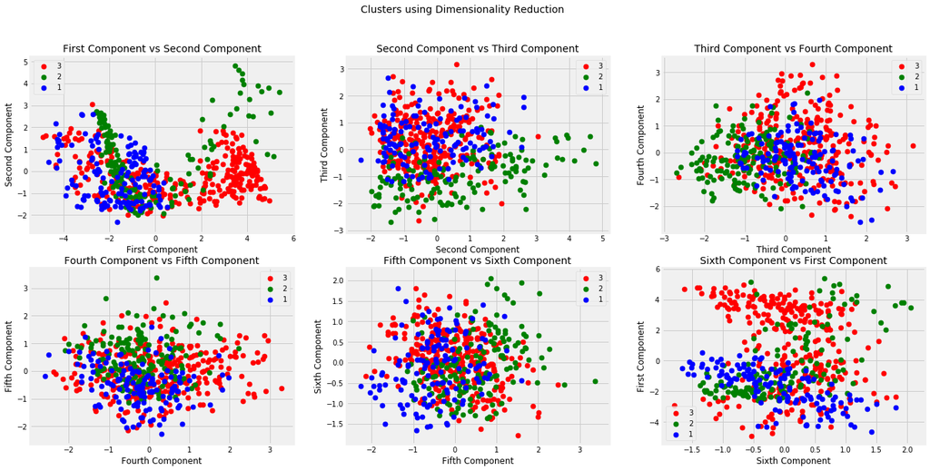

```python
f, ((ax1, ax2, ax3), (ax4, ax5, ax6)) = plt.subplots(2, 3, figsize = (20, 10))
f.suptitle('Clusters using Dimensionality Reduction', fontsize = 14)

pca_plots(vehicle_train, 0, 1, 'First Component', 'Second Component', ax1)
pca_plots(vehicle_train, 1, 2, 'Second Component', 'Third Component', ax2)
pca_plots(vehicle_train, 2, 3, 'Third Component', 'Fourth Component', ax3)
pca_plots(vehicle_train, 3, 4, 'Fourth Component', 'Fifth Component', ax4)
pca_plots(vehicle_train, 4, 5, 'Fifth Component', 'Sixth Component', ax5)
pca_plots(vehicle_train, 5, 0, 'Sixth Component', 'First Component', ax6)
```

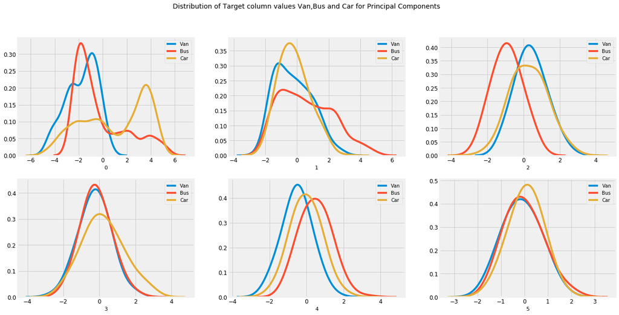

```python
features = [f for f in vehicle_train.columns if f not in ['class']]

i = 0
out1 = vehicle_train[vehicle_train['class'] == 1]
out2 = vehicle_train[vehicle_train['class'] == 2]
out3 = vehicle_train[vehicle_train['class'] == 3]

fig, ax = plt.subplots(2, 3, figsize = (20, 10))
fig.suptitle('Distribution of Target column values Van,Bus and Car for Principal Components', fontsize = 14)

for feature in features:
    i += 1
    plt.subplot(2, 3, i)
    sns.kdeplot(out1[feature], bw = 0.5, label = 'Van')
    sns.kdeplot(out2[feature], bw = 0.5, label = 'Bus')
    sns.kdeplot(out3[feature], bw = 0.5, label = 'Car')
    plt.xlabel(feature, fontsize = 11)
    locs, labels = plt.xticks()
    plt.tick_params(axis = 'both', which = 'major', labelsize = 12)
plt.show()
```

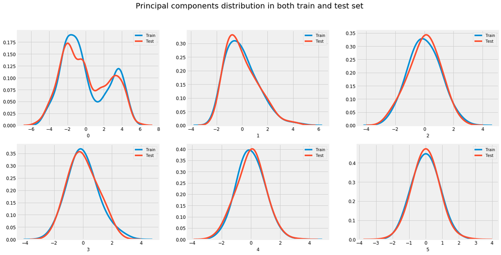

```python
#Prinicipal Components distribution in both train and test set
i = 0
features_train = vehicle_train.drop(['class'], axis = 1)
features_test = vehicle_test.drop(['class'], axis = 1)

fig, ax = plt.subplots(2, 3, figsize = (20, 10))
fig.suptitle('Principal components distribution in both train and test set', fontsize = 20)

for feature in features:
    i += 1
    plt.subplot(2, 3, i)
    sns.kdeplot(features_train[feature], bw = 0.5, label = 'Train')
    sns.kdeplot(features_test[feature], bw = 0.5, label = 'Test')
    plt.xlabel(feature, fontsize = 12)
    locs, labels = plt.xticks()
    plt.tick_params(axis = 'both', which = 'major', labelsize = 12)
plt.show();
```

Most of the principal components are normally distributed in both train and test set

```
SVC Scores with Hyperparameter Tuning using Principal Components


Best Hyper Parameters are:  {'C': 1, 'kernel': 'rbf'}
Best Score is:  0.905
SVC accuracy score for train set: 0.924
SVC accuracy score for test set: 0.740
SVC cross validation training score:  0.902

Accuracy Score:
 0.74

              precision    recall  f1-score   support

         1.0       0.66      0.75      0.70        59
         2.0       0.68      0.69      0.69        62
         3.0       0.81      0.76      0.79       133

    accuracy                           0.74       254
   macro avg       0.72      0.73      0.72       254
weighted avg       0.75      0.74      0.74       254
```

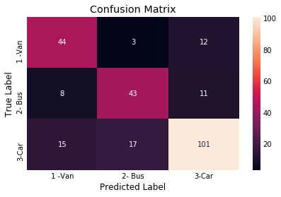

|  | SVM_PCA |
| --- | --- |
| Accuracy score | 0.74 |
| Cross Validation score | 0.902 |

```python
# Build SVC Model with hyperparameter tuning using Principal Components
#Perform K-fold cross validation and get the cross validation score as well
svc_pca = SVC(random_state = random_state)

params_pca = {'C': [0.01, 0.05, 0.5, 1], 'kernel': ['linear', 'rbf']}

skf_pca = StratifiedKFold(n_splits = 10, random_state = random_state)
grid_svc_pca = GridSearchCV(svc_pca, param_grid = params_pca, n_jobs = -1, cv = skf_pca)

grid_svc_pca.fit(X_train_min, y_train)

print('SVC Scores with Hyperparameter Tuning using Principal Components\n\n')
print('Best Hyper Parameters are: ', grid_svc_pca.best_params_)
print('Best Score is: ', grid_svc_pca.best_score_.round(3))

print('SVC accuracy score for train set: {0:.3f}'.format(grid_svc_pca.score(X_train_min, y_train)))
print('SVC accuracy score for test set: {0:.3f}'.format(grid_svc_pca.score(X_test_min, y_test)))

y_true, y_pred = y_test, grid_svc_pca.predict(X_test_min)

# Cross Validation Score
Best_scoring = 'accuracy'
grid_svc_score_pca = cross_val_score(grid_svc_pca, X_train_min, y_train, cv = skf_pca, scoring = Best_scoring)
print('SVC cross validation training score: ', round(grid_svc_score_pca.mean(), 3).astype(str))

# Accuracy Score
acc_pca = accuracy_score(y_true, y_pred)
print('\nAccuracy Score:\n', acc_pca.round(3))

# Classification Report
print('\n{}'.format(classification_report(y_true, y_pred)))

# Confusion Matrix
cm_pca = confusion_matrix(y_true, y_pred)
label = ["1 -Van", "2- Bus", "3-Car"]
cm1_pca = pd.DataFrame(cm_pca,index = label, columns = label)
sns.heatmap(cm1_pca, annot = True, fmt = "d")
plt.title("Confusion Matrix")
plt.xlabel("Predicted Label")
plt.ylabel("True Label")
plt.show()

#Store the accuracy score results of SVM with Principal components for final comparison
data_pca=[acc_pca.round(3),round(grid_svc_score_pca.mean(), 3).astype(str)]
pcadf = pd.DataFrame(data_pca ,index= ['Accuracy score','Cross Validation score'] ,columns =['SVM_PCA'])
pcadf
```

# 8. Compare the accuracy scores and cross validation scores of Support vector machines – one trained using raw data and the other using Principal Components, and mention your findings

```python
pd.concat([rawdf, pcadf], axis=1)
```

|  | SVM_Raw | SVM_PCA |
| --- | --- | --- |
| Accuracy score | 0.93 | 0.74 |
| Cross Validation score | 0.936 | 0.902 |

Accuracy score of SVM_Raw data is 93 % but with Principal components ,it's 74% Cross Validation score of SVM_Raw data is 0.936 but with Principal components , its 0.902. Using Principal components, reduced the dimensions from 12 to 6 and employed feature selection which explained 95% variance of the Vehical Dataset. Effect of PCA can be highly applicable in large volume of datasets with multiple features /dimensions.

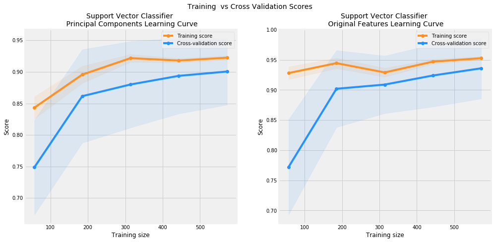

```python
# Plot training  vs cross validation scores
cv = StratifiedKFold(n_splits = 30, random_state = random_state)

f, ((ax1, ax2 )) = plt.subplots(1, 2, figsize = (15, 7.2))
f.suptitle('Training  vs Cross Validation Scores', fontsize = 14)

plot_learning_curve(grid_svc_pca, X_train_min, y_train, cv = cv, n_jobs = 1, ax = ax1,
                    name = 'Support Vector Classifier \n Principal Components Learning Curve')

plot_learning_curve(grid_svc_f_raw, X_train, y_train, cv = cv, n_jobs = 1, ax = ax2,
                    name = 'Support Vector Classifier \n Original Features Learning Curve')
```

# Conclusion

PCA technique used to reduce the dimensionality of the dataset by the selecting the most important features that captures maximum information about the dataset .Here,we've reduced the dimension from 12 to 6 and selected those which explained 95% variance as it removes correlated features. after implementing PCA on the dataset, we saw features getting converted into principal components. Principal components are the linear combination of original features. This makes the features less interpretable. Additionally, we know that one of limitation of PCA is it assumes linearity i.e. principal components are a linear combinations of the original features

Shape of dataset we were dealing with was 846 rows and 12 features + 1 class column. Effect of PCA can be more useful in Big datasets with multiple features.

From the Learning curve,Both training and validation scores are volatile. For SVC with principal components and original features, both training and validation scores increases with the increase in size of the dataset, which would mean the scores can be further increases with more training samples. However, the gap between training and validation score for SVC with principal component is higher than then the SVM with Raw data.